# HW 8 - Simulations

Keanu Rochette

2025-03-12

## Load libraries

```r
# Data manipulation and visualization
library(tidyverse)
library(here)
#library(janitor)
library(gt)
library(gtExtras)

# Data analysis/statistics
#library(glmmTMB)
library(car) #ANOVA
library(MASS)
#library(ggeffects)
#library(effects) #dependency for ggeffects
```

## Question 1

```r
set.seed(123)  # For reproducibility

# Initial conditions
trmt_avg <- 460
control_avg <- 415
sd_exp <- 110
nsims <- 1000
```

*1. Start by assuming three replicates each of the treatment and control plots.* *2. Perform 1000 simulations, where each time you draw three treatment ANPP values and three control ANPP values, using the appropriate means and standard deviation, from a normal distribution.*

*3. For each random draw, fit a linear model testing for a treatment effect. Save the p-value from an F-test for the treatment effect (you can extract this with Anova(model)$P[1]).* *4. Also save the model coefficient that quantifies the difference between the treatment and control groups. At the end you should have 1000 p-values and 1000 coefficient values.* *5. What proportion of the p-values are less than 0.05? This is your statistical power, under this design, effect size, and residual noise.* *6. Now repeat this whole process using different numbers of replicates: 5, 10, 20, 50, 100.* *7. Plot the statistical power vs. the number of replicates.* *8. How much replication do you need to achieve a power of 0.25? This means that when there is a real treatment effect, you will detect it (only) 25% of the time.*

```r
p_values <- numeric(nsims)  # Store p-values
coefficients <- numeric(nsims)  # Store treatment effect estimates
```

```r
# create a function that can do the simluations for us
set.seed(123)  # For reproducibility

experiment <- function(trmt_avg = 460, control_avg = 415, sd_exp = 110,
                       nsims = 1000, replicates) {

  treatment <- factor(rep(c("Control", "Treatment"), each = replicates))

  for (i in 1:nsims) {
  #random values for the treatments
    treatment_values <- rnorm(replicates, mean = trmt_avg, sd = sd_exp)
  #random values for the controls
    control_values <- rnorm(replicates, mean = control_avg, sd = sd_exp)

    exp_df <- tibble(
      ANPP = c(treatment_values, control_values),
      treatment = treatment
    )

    model <- lm(ANPP ~ treatment, data = exp_df)

    p_values[i] <<- Anova(model)$P[1]

    coefficients[i] <<- summary(model)$coefficients[2]
  }
}
```

```r
# for 3 replicates
experiment(replicates =3)
head(p_values)
```

```
## [1] 0.9763544 0.5408122 0.8123594 0.2400793 0.8726936 0.9043957
```

```r
head(coefficients)
```

```
## [1]  -2.950449  51.405156 -31.707108 -86.565751  18.909877   4.934002
```

```r
stat_power_3 <- mean(p_values < 0.05)
stat_power_3
```

```
## [1] 0.068
```

```r
# for 5 replicates
experiment(rep = 5)
head(p_values)
```

```
## [1] 0.3749876 0.1721104 0.3611584 0.0380600 0.4990207 0.3504140
```

```r
stat_power_5 <- mean(p_values < 0.05)
```

```r
# for 10 replicates
experiment(rep = 10)
head(p_values)
```

```
## [1] 0.72032453 0.85855503 0.36028816 0.10506521 0.02938125 0.74938331
```

```r
stat_power_10 <- mean(p_values < 0.05)
```

```r
# for 20 replicates
experiment(rep = 20)
stat_power_20 <- mean(p_values < 0.05)
```

```r
# for 25 replicates
experiment(rep = 25)
stat_power_25 <- mean(p_values < 0.05)
```

```r
# for 50 replicates
experiment(rep = 50)
stat_power_50 <- mean(p_values < 0.05)
```

```r
# for 100 replicates
experiment(rep = 100)
stat_power_100 <- mean(p_values < 0.05)
```

```r
# save the p_values and the stat power in a dataframe
stat_pow_df <- tibble(
  rep = c(3, 5, 10, 20, 25, 50, 100),
  stat_pow = c(stat_power_3,stat_power_5,stat_power_10,
               stat_power_20, stat_power_25, stat_power_50,stat_power_100)
)
stat_pow_df
```

```
## # A tibble: 7 × 2
##     rep stat_pow
##   <dbl>    <dbl>
## 1     3    0.068
## 2     5    0.092
## 3    10    0.141
## 4    20    0.227
## 5    25    0.293
## 6    50    0.513
## 7   100    0.809
```

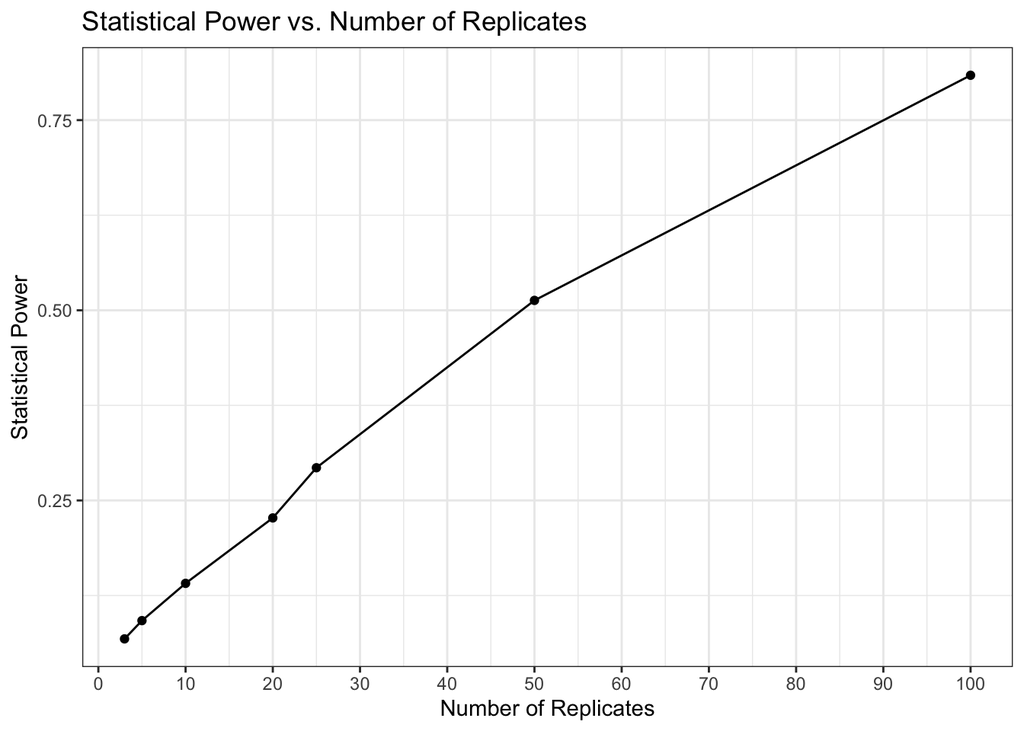

```r
# plotting the replicates and the stat power.
ggplot(stat_pow_df, aes(x = rep, y = stat_pow)) +
  geom_point() +
  geom_line() +
  labs(
    title = "Statistical Power vs. Number of Replicates",
    x = "Number of Replicates",
    y = "Statistical Power") +
  scale_x_continuous(breaks = seq(from = 0, to = 100, by = 10))+
  scale_y_continuous(breaks = seq(from = 0, to = 1, by = 0.25))+
  theme_bw()
```

### Answer Q1

You need at least 21 replicates to get 25% statistical power.

## Question 2

```r
#create empty tibble to save future mean coefficients
coef_df <- tibble(
  rep = numeric(),
  coef = numeric()
)

# list of the replicates
replicates <- c(3, 5, 10, 20, 25, 50, 100)
```

```r
## Somehow my coefficients have negative values. I'm not sure if that's correct. However, due to later questions, I use the absolute value of the coefficients for my answers in the hw.

# for loop to automate the calculation of the coefficients so I dont have to do it by hand like in Q1

for (i in 1:length(replicates)){
  rep <- replicates[i]
  experiment(rep = rep) # run the function that does the simulations
  coef <- mean(coefficients[p_values<0.05])

  tib <- tibble(rep=rep, coef=coef)
  coef_df <- bind_rows(coef_df, tib)
}

# print coef data frame
coef_df
```

```
## # A tibble: 7 × 2
##     rep   coef
##   <dbl>  <dbl>
## 1     3 -157.
## 2     5 -130.
## 3    10 -114.
## 4    20  -85.3
## 5    25  -80.9
## 6    50  -60.8
## 7   100  -50.6
```

```r
#calcultating the magnitude difference of the generated mean coefficients.

coef_df %>%
  mutate(magnitude_difference = coef+46)
```

```
## # A tibble: 7 × 3
##     rep   coef magnitude_difference
##   <dbl>  <dbl>                <dbl>
## 1     3 -157.               -111.
## 2     5 -130.                -83.6
## 3    10 -114.                -67.9
## 4    20  -85.3               -39.3
## 5    25  -80.9               -34.9
## 6    50  -60.8               -14.8
## 7   100  -50.6                -4.58
```

### Answer Q2

*How does the mean of the significant coefficients change as the number of replicates increases? Recall that because this is a simulation, we know the true value of the treatment difference: it’s 461 - 415 = 46.* *How much larger is the simulated value from the significant experiments, compared to the true value? This is the type M error.* *What are the potential implications for our understanding of climate change, if most warming experiments have low power?*

- The mean of the significant coefficients gets closer to 0 as the number of replicates increases.
- If climate models have low power, then that would mean that the models produce inflated values in their results. Warming temperatures may be lower than expected my the models